# R-Group Decomposition Tutorial

tutorial

rgd

Getting started with RGD

Published

January 9, 2023

R-group decomposition (RGD) is a standard approach for analyzing chemical datasets and doing SAR analysis. Of course the RDKit provides code supporting RGD. Since there are a lot of different RGD use cases, and it turns out that doing R-group decomposition and providing *useful* results on arbitrary datasets is considerably more complicated than it may initially seem, the RDKit’s RGD implementation needs to be quite flexible (and the implementation is fairly complex). Unfortunately the code is also quite “underdocumented”… this tutorial is a first pass at fixing that. It will eventually end up in the RDKit documentation.

Here I will demonstrate some of the more useful (in my opinion) options of the RGD code using some real-world datasets. I may revisit this topic at some point in the future to explain some of the more advanced topics. If there are pieces you think I should cover, please let me know in the comments!

Other RGD-related blog posts:

1. [R-Group Decomposition: Edge Cases](https://greglandrum.github.io/rdkit-blog/posts/2023-01-05-rgd-edge-cases.html)
2. [R-Group Decomposition and Highlighting](https://greglandrum.github.io/rdkit-blog/posts/2021-08-07-rgd-and-highlighting.html)
3. [R-group decomposition and molzip](http://localhost:4665/posts/2022-03-14-rgd-and-molzip.html)

You can also use the [rgd tag](https://greglandrum.github.io/rdkit-blog/#category=rgd) to find these.

The first two datasets I’ll use in this post are created using the SMILES provided in the Supplementary Information from a couple of open-acess J Med Chem papers (Aside: isn’t it great that J. Med. Chem. encourages authors to provide SMILES for the structures in their papers and so many authors actually do so? Isn’t it depressing that the journals which focus on computational topics don’t do so?).

```python
from rdkit import Chem
from rdkit.Chem import Draw
from rdkit.Chem.Draw import IPythonConsole
import pandas as pd
from rdkit.Chem import PandasTools
PandasTools.RenderImagesInAllDataFrames(images=True)
import rdkit
print(rdkit.__version__)
```

```
2022.09.1
```

```python
import os
baseDir = '../data/RGD_sets'
```

# The basics

Here’s our first dataset, from https://pubs.acs.org/doi/10.1021/acs.jmedchem.8b00883

```python
df = PandasTools.LoadSDF(os.path.join(baseDir,'jm8b00883.sdf'))
mols = df.ROMol.to_list()
Draw.MolsToGridImage(mols[:12],subImgSize=(300,250))
```

[figure not shown]

These datasets include the core query as the first element in the file (I added this, it was not in the original paper), so pull that out:

```python
core = mols.pop(0)
core
```

[figure not shown]

Bring in the RGD module

```python
from rdkit.Chem import rdRGroupDecomposition
```

Here’s a quick demo of the basic usage of the RGD code. The return value is a 2-tuple: 1. the RGD results 2. a list with the indices of molecules which did not match any of the cores

```python
rgd,fails = rdRGroupDecomposition.RGroupDecompose([core],mols)
fails
```

```
[14:15:53] No core matches
```

```
[15]
```

In this case the molecule at position 15 did not match our core:

```python
mols[15]
```

[figure not shown]

The output is a list with one entry per matching molecule. Each entry in the list is a dictionary with the core match and R groups for the corresponding molecule:

```python
rgd[:2]
```

```
[{'Core': <rdkit.Chem.rdchem.Mol at 0x7fbeb7aeac00>,
  'R1': <rdkit.Chem.rdchem.Mol at 0x7fbeb7aeac70>,
  'R2': <rdkit.Chem.rdchem.Mol at 0x7fbeb7aeace0>,
  'R3': <rdkit.Chem.rdchem.Mol at 0x7fbeb7aead50>,
  'R4': <rdkit.Chem.rdchem.Mol at 0x7fbeb7aeadc0>,
  'R5': <rdkit.Chem.rdchem.Mol at 0x7fbeb7aeae30>},
 {'Core': <rdkit.Chem.rdchem.Mol at 0x7fbeb7aeaea0>,
  'R1': <rdkit.Chem.rdchem.Mol at 0x7fbeb7aeaf10>,
  'R2': <rdkit.Chem.rdchem.Mol at 0x7fbeb7aeaf80>,
  'R3': <rdkit.Chem.rdchem.Mol at 0x7fbeb7aeaff0>,
  'R4': <rdkit.Chem.rdchem.Mol at 0x7fbeb7aeb060>,
  'R5': <rdkit.Chem.rdchem.Mol at 0x7fbeb7aeb0d0>}]
```

Let’s look at the results from the first row:

```python
Draw.MolsToGridImage(rgd[0].values(),legends=rgd[0].keys())
```

[figure not shown]

If you want to quickly look at the results from the RGD, it can be convenient to just display them in a Pandas DataFrame. The `PandasTools` module includes a function to make this easy. The function, `RGroupDecompositionToFrame()`, needs the results from the RGD in a different format, which we can get by calling `RGroupDecompose()` with the keyword argument `asRows=False`:

```
[14:15:53] No core matches
```

Mol

R1

R2

R3

R4

R5

0

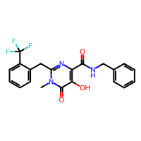

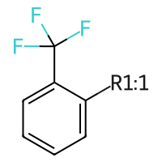

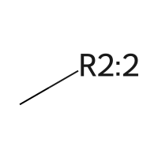

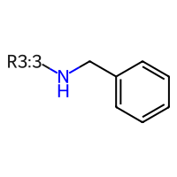

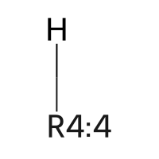

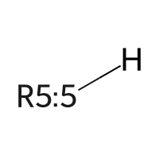

1

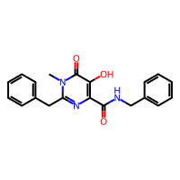

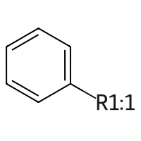

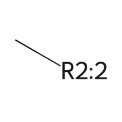

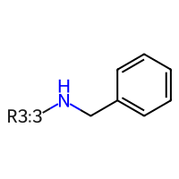

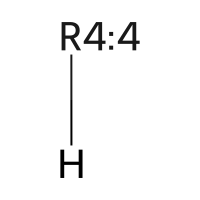

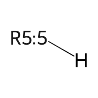

2

[18 more figures not shown]

```python
crgd,fails = rdRGroupDecomposition.RGroupDecompose([core],mols,asRows=False)
PandasTools.RGroupDecompositionToFrame(crgd,[mols[i] for i in range(len(mols)) if i not in fails],).head()
```

When called this way, `RGroupDecompose()` returns a dictionary of lists instead of a list of dictionaries:

```python
crgd,fails = rdRGroupDecomposition.RGroupDecompose([core],mols,asRows=False)
crgd.keys()
```

```
[14:15:53] No core matches
```

```
dict_keys(['Core', 'R1', 'R2', 'R3', 'R4', 'R5'])
```

```python
len(mols),len(crgd['Core']),len(crgd['R1'])
```

```
(18, 17, 17)
```

The core we provided has three labelled R groups, but the RGD produced five different R labels. The other labels were automatically assigned when molecules with additional substituents were encountered. This behavior can be disabled using the `onlyMatchAtRGroups` parameter when calling `RGroupDecompose`:

```python
ps = rdRGroupDecomposition.RGroupDecompositionParameters()
ps.onlyMatchAtRGroups = True
rgd,fails = rdRGroupDecomposition.RGroupDecompose([core],mols,options = ps)
fails
```

```
[14:15:54] No core matches
[14:15:54] No core matches
[14:15:54] No core matches
```

```
[14, 15, 16]
```

Now there are three molecules which didn’t match: 15 from before and then 14 and 16, which had additional substituents. The other molecules only have R1-R3:

```python
rgd[0]
```

```
{'Core': <rdkit.Chem.rdchem.Mol at 0x7fbeb5a9e5e0>,
 'R1': <rdkit.Chem.rdchem.Mol at 0x7fbeb5a9e650>,
 'R2': <rdkit.Chem.rdchem.Mol at 0x7fbeb5a9e6c0>,
 'R3': <rdkit.Chem.rdchem.Mol at 0x7fbeb5a9e730>}
```

## Working without R labels

It’s also possible to do RGD by providing a core without labeled R groups:

```python
core_without_labels = Chem.MolFromSmarts('Cc1nc(=O)c(O)c(C=O)n1')
core_without_labels
```

[figure not shown]

```
1
```

```
[14:15:54] No core matches
```

Mol

R1

R2

R3

R4

0

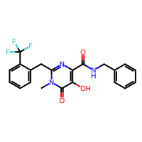

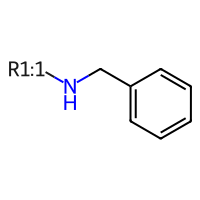

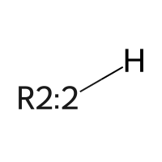

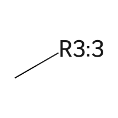

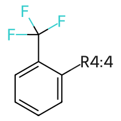

1

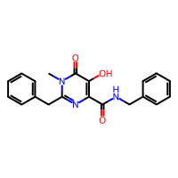

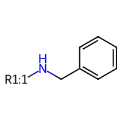

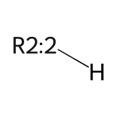

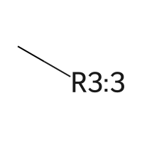

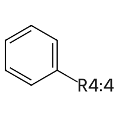

2

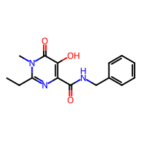

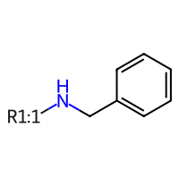

[13 more figures not shown]

```python
crgd,fails = rdRGroupDecomposition.RGroupDecompose([core_without_labels],mols,asRows=False)
print(len(fails))
PandasTools.RGroupDecompositionToFrame(crgd,[mols[i] for i in range(len(mols)) if i not in fails],).head()
```

Here the R labels are automatically assigned, but the result is otherwise the same as what we saw above.

# Handing of chirality

For this we’ll use a new dataset, from https://pubs.acs.org/doi/10.1021/acs.jmedchem.5b00752

Once again, I manually constructed the core when putting these datasets together.

```python
df = PandasTools.LoadSDF(os.path.join(baseDir,'jm5b00752.sdf'))
mols = df.ROMol.to_list()
Draw.MolsToGridImage(mols[:12],subImgSize=(300,250))
```

[figure not shown]

```python
core = mols.pop(0)
core
```

[figure not shown]

```python
from rdkit import RDLogger
```

```python
RDLogger.DisableLog('rdApp.debug') # <- disables the "no core matches" message
crgd,fails = rdRGroupDecomposition.RGroupDecompose([core],mols,asRows=False)
len(fails),len(mols)
```

```
(36, 59)
```

In this case there were 36 molecules in the SI which didn’t match our core query. Let’s look at the ones which did:

Mol

R1

R3

R4

0

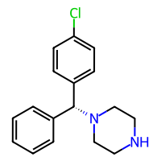

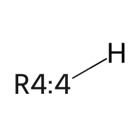

1

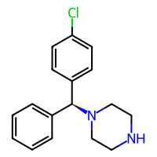

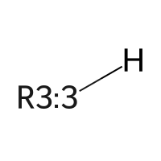

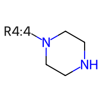

2

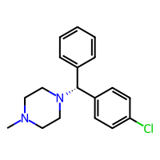

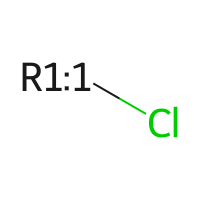

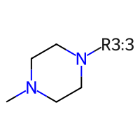

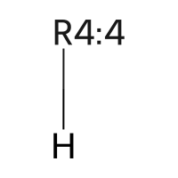

3

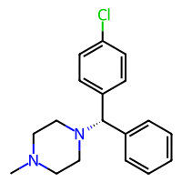

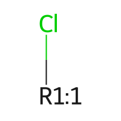

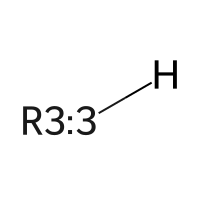

[5 more figures not shown]

```python
df = PandasTools.RGroupDecompositionToFrame(crgd,[mols[i] for i in range(len(mols)) if i not in fails])
df.head()
```

Notice that we have drawn the core with a wedged bond, indicating chirality.

What if we use a core without chirality indicated? One easy way to do this is to “turn off” the chirality flag directly:

```python
core_cp = Chem.Mol(core)
core_cp.GetAtomWithIdx(0).SetChiralTag(Chem.ChiralType.CHI_UNSPECIFIED)
core_cp
```

[figure not shown]

```
8
```

Mol

R1

R2

R3

R5

0

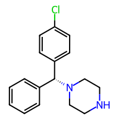

1

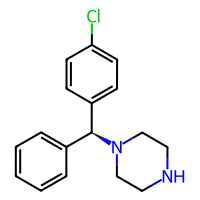

2

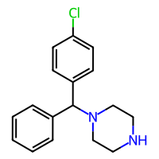

3

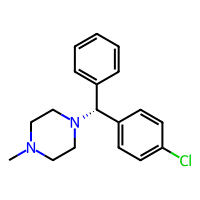

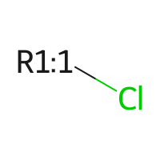

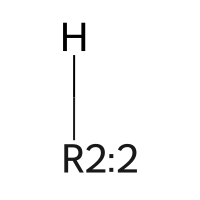

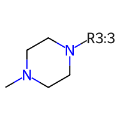

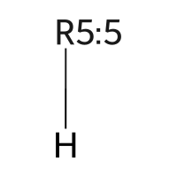

4

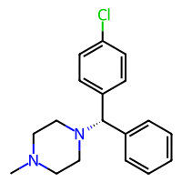

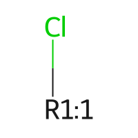

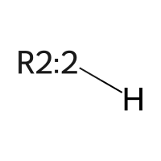

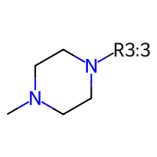

[1 more figures not shown]

```python
crgd,fails = rdRGroupDecomposition.RGroupDecompose([core_cp],mols,asRows=False)
print(len(fails))
df = PandasTools.RGroupDecompositionToFrame(crgd,[mols[i] for i in range(len(mols)) if i not in fails])
df.head()
```

This time the usual R group symmetrization has been applied and we end up with the piperazines all in R3

It’s also worth pointing out that this result set has a lot less failures - 8 instead of 36 with the original query. We can see one of the extra results in this excerpt from the results table: the third row is a molecule where chirality hasn’t been specified for the central atom.

We can accomplish the same thing without actually modifying the core itself by telling the RGD code to ignore chirality when doing its substructure search.

In the interest of not having this post contain gigabytes of images, here I’m just showing the results as SMILES:

```python
ps = rdRGroupDecomposition.RGroupDecompositionParameters()
ps.substructMatchParams.useChirality=False
rgd,fails = rdRGroupDecomposition.RGroupDecompose([core],mols,asRows=True,asSmiles=True,options=ps)
print(len(fails))
for row in rgd[:5]:
    row.pop('Core')
    print(row)
```

```
8
{'R1': 'Cl[*:1]', 'R2': '[H][*:2]', 'R3': 'C1CN([*:3])CCN1', 'R5': '[H][*:5]'}
{'R1': 'Cl[*:1]', 'R2': '[H][*:2]', 'R3': 'C1CN([*:3])CCN1', 'R5': '[H][*:5]'}
{'R1': 'Cl[*:1]', 'R2': '[H][*:2]', 'R3': 'C1CN([*:3])CCN1', 'R5': '[H][*:5]'}
{'R1': 'Cl[*:1]', 'R2': '[H][*:2]', 'R3': 'CN1CCN([*:3])CC1', 'R5': '[H][*:5]'}
{'R1': 'Cl[*:1]', 'R2': '[H][*:2]', 'R3': 'CN1CCN([*:3])CC1', 'R5': '[H][*:5]'}
```

These are the same results as we saw before.